# Evolution récentes de l’immobilier dans la commune d’Houilles (1er semestre 2025)

Rapport confidentiel pour Margherita Piazza

Author

Nassim ADJMI

Published

November 25, 2025

### Objectifs

La présidente directrice générale de l’agence immobilière Piazza Margherita vous propose un nouveau défi : réaliser une étude statistique à finalité opérationnelle visant à sélectionner facilement les annonces en fonction des demandes des clients et de leurs capacités financières. L’étude portera uniquement sur le premier semestre 2025 et comportera donc un petit échantillon de ventes ayant eu lieu récemment dans votre commune (Source : Demandes de valeurs foncières, Etalab, 2025).

[figure not shown]

## A. INTRODUCTION (3 pts)

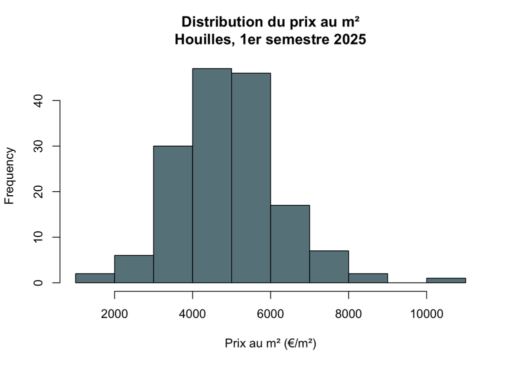

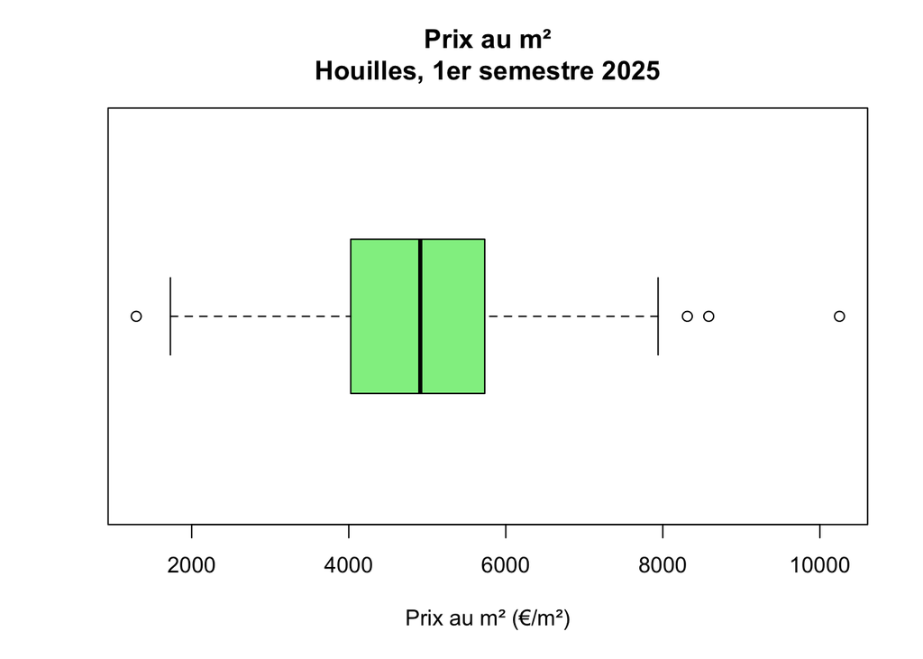

Au premier semestre 2025, le marché immobilier de **Houilles** a enregistré **158 ventes**, issues exclusivement de transactions individuelles.  
La commune présente ainsi un échantillon suffisamment varié pour fournir une analyse opérationnelle destinée à conseiller efficacement les clients de l’agence Piazza Margherita.

#### Répartition des biens vendus:

Les ventes sont équilibrées entre :

-> **78 appartements**

-> **80 maisons**

Ces transactions couvrent une large diversité de biens, ce qui permet une analyse statistique cohérente pour accompagner les choix d’investissement de nos clients.

#### Prix des biens:

Les prix s’échelonnent entre **79350€ et 962000€** avec :

-> **Une médiane de 323200€,** -> **Une moyenne de 370976€.**

Autrement dit, la moitié des biens vendus à Houilles se situent dans la tranche 224 000€ - 466 000€, signe d’un marché actif de classe moyenne, mais tiré vers le haut par quelques maisons haut de gamme.

#### Surfaces observées:

Les logements vendus affichent des surfaces comprises **entre 19 m² et 175 m²**, avec :

-> **Une médiane de 70,5 m²**

-> **Une moyenne de 75,98 m²**

On retrouve le profil typique d’une commune résidentielle francilienne : appartements majoritairement entre 40 et 70 m², et maisons dans la tranche 90–120 m².

#### Prix au mètre carré:

Le prix au m² varie de 1 294€/m² à 10 250€/m²,(après filtrage des valeurs extrêmes). Les valeurs centrales sont :

-> **Médiane de 4911€/m²**

-> **Moyenne de 4958€/m²**

La distribution du prix au m² est légèrement asymétrique vers la droite, en raison de quelques biens plus chers tirant la queue de distribution vers le haut. La majorité des logements se situent toutefois entre 4000€/m² et 6000€/m².

## B. PRIX EN FONCTION DU NOMBRE DE PIECES (7 pts)

Notre compagnie souhaite déterminer facilement le type de logement que l’on proposera à un client en fonction du prix que ce client est prêt à payer. On classe les logements en trois types de besoins selon le nombre de pièces.

### B.1 Cas des petits logements de 1 ou 2 pièces (2 pts)

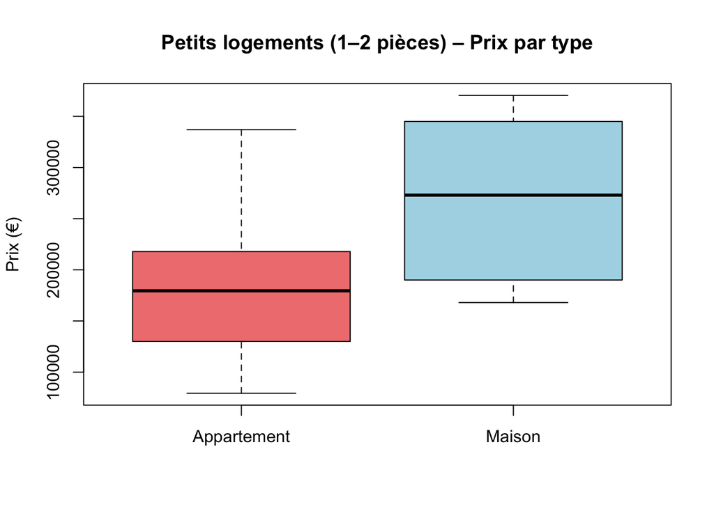

Sur les **34 petites surfaces vendues**, une écrasante majorité sont des **appartements (28 ventes)** et seulement **6 maisons**, ce qui correspond parfaitement au marché local : les studios et deux-pièces sont surtout destinés aux étudiants, jeunes actifs ou investisseurs locatifs.

Les prix observés diffèrent sensiblement selon le type :

-> **Appartement : Médiane ≈ 179495€, Moyenne ≈ 180245€**

-> **Maison : Médiane ≈ 273000€, Moyenne ≈ 269917€**

Le test de Student indique une différence statistiquement significative **(p≈0,0407)** et le test de Wilcoxon la confirme **(p≈0,0176)**. Les deux méthodes convergent.

#### Interprétation

**Les petites maisons sont rares** et se vendent nettement plus cher que les petits appartements, en moyenne **+90000€ d’écart.**

Un jeune acheteur ou un investisseur devra clairement s’orienter vers un appartement. Les petites maisons existent, mais leur prix les positionne plutôt comme un produit de niche.

### B.2 Cas logements standard de 3 ou 4 pièces (2 pts)

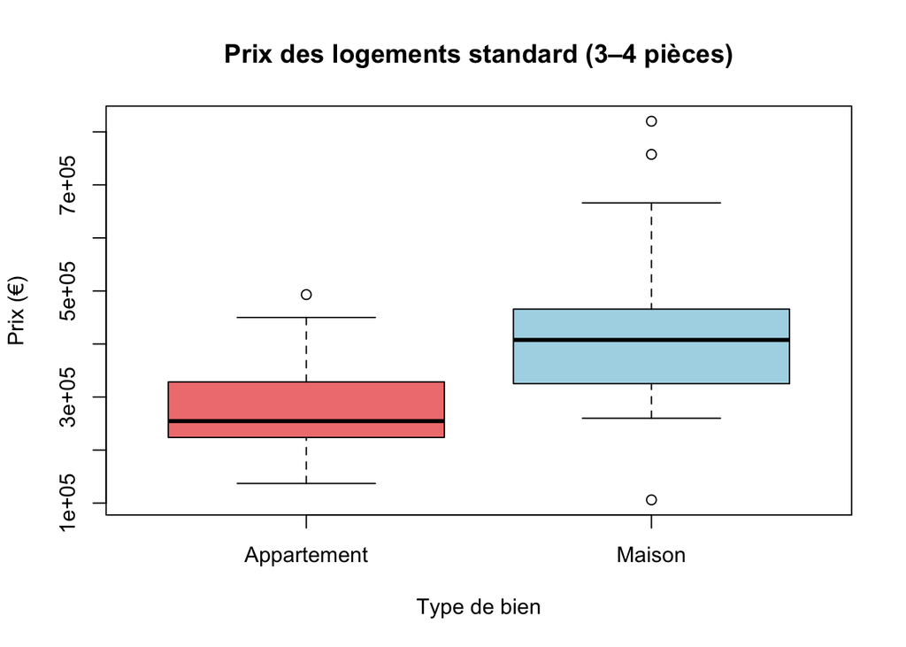

Les logements standard constituent le cœur du marché : **86 ventes,** réparties en **46 appartements** et **40 maisons**.

C’est le marché des familles, des couples avec un premier enfant, souvent en quête de stabilité sans quitter l’Île-de-France.

Les niveaux de prix diffèrent fortement selon le type :

-> **Appartement : Médiane ≈ 254650€, Moyenne ≈ 277899€**

-> **Maison : Médiane ≈ 407631€, Moyenne ≈ 423177€**

Les tests statistiques confirment une différence très nette :

**Student : p < 0,0000002**

**Wilcoxon : p ≈ 1,07e−08**

#### Interprétation

Pour une famille souhaitant s’installer durablement, la maison implique **un surcoût important, souvent entre 150000€ et 180000€**

### B.3 Cas des grands logements de 5 pièces ou plus (2 pts)

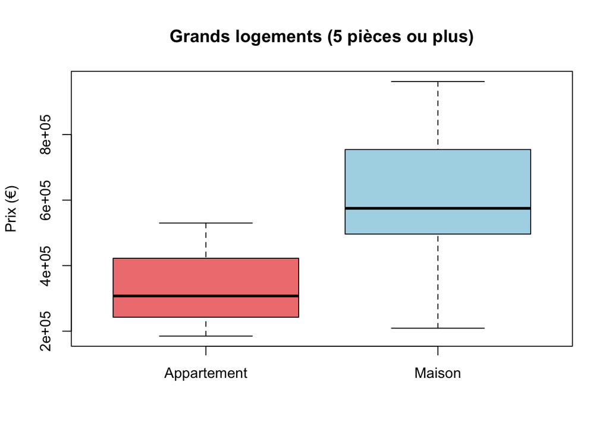

Les grands logements représentent **38 ventes**, dont **34 maisons** et seulement **4 appartements.** Ce segment correspond clairement aux grandes familles, aux ménages cherchant une surface de confort ou un jardin.

Voici les niveaux de prix observés :

→ **Appartement : Médiane ≈ 307500€, Moyenne ≈ 332500€** → **Maison : Médiane ≈ 575000€, Moyenne ≈ 614923€**

Malgré la petite taille de l’échantillon côté appartements, les tests indiquent une différence significative :

-> **Student : p≈0,021**

-> **Wilcoxon : p≈0,0117**

Les deux méthodes convergent à nouveau.

#### Interprétation

À Houilles, **les grands appartements n’existent quasiment pas.** La quasi-totalité des grands volumes sont des **maisons familiales**, souvent sur 2 niveaux, avec jardin, et donc **beaucoup plus chères.**

L’écart est massif : **environ +300000€ en moyenne** pour passer d’un grand appartement (rare) à une grande maison (standard du marché).

➡️ Conseil d’agent immobilier : Une famille nombreuse ou un ménage recherchant du volume devra s’orienter vers une maison. Les grands appartements peuvent apparaître ponctuellement, mais ils ne constituent pas une offre fiable.

### B.4 Synthèse (1 pt)

| Budget du client | Appartement typique | Maison typique |
| --- | --- | --- |
| **≤ 224062€** | 2 pièces | Petite maison rare (2–3 pièces) |
| **224062–323200€** | 3–4 pièces | 3 pièces |
| **323200–466275€** | 3–4 pièces | 4 pièces |
| **≥ 466275€** | 4–5 pièces | 5 pièces et plus |

## C. SURFACE EN FONCTION DU PRIX (8 pts)

Notre compagnie souhaite construire un modèle statistique permettant de prévoir la surface du logement que peut espérer un client en fonction du prix qu’il est prêt à payer. En différenciant évidememnt le cas des clients qui souhaient acquérir une maison ou un appartement.

### C.1 Cas des maisons (3 pts)

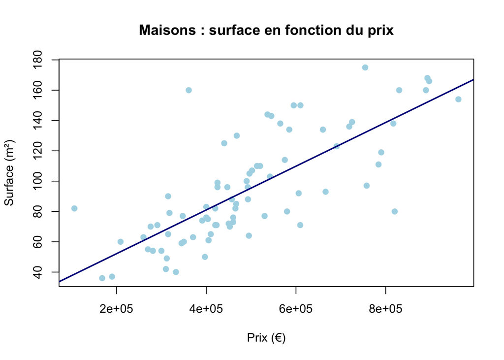

#### Analyse

Le lien entre prix et surface est très fort dans le cas des maisons :

-> **Corrélation ≈ 0,75, très élevée**

-> **Test de corrélation : p < 0,000000000000001, donc relation clairement significative**

Le lien entre le prix et la surface des maisons est très fort (corrélation ≈ 0,75, p < 10⁻¹⁵). Le modèle montre qu’à Houilles, **chaque tranche de 100000€ supplémentaire apporte en moyenne environ +14 m² de surface.**

**Pour un client disposant de 600000€**, la surface attendue est **d’environ 110 m²**, ( avec un intervalle raisonnable compris entre 63 m² et 157 m², selon l’état, la localisation et le terrain).

Un budget de 600000€ permet donc d’accéder à une maison familiale confortable.

### C.2 Cas des appartements (3 pts)

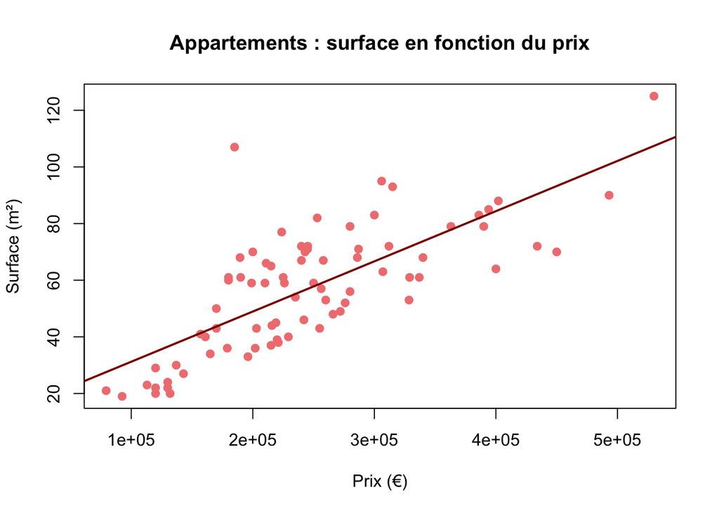

Le lien entre prix et surface est aussi très fort dans le cas des appartements :

-> **Corrélation ≈ 0,75, très élevée**

-> **Test de corrélation : p < 0,00000000000001, donc relation clairement significative**

Chez les appartements, la relation prix/surface est également très forte (corrélation ≈ 0,75, p < 10⁻¹⁴). Le modèle suggère que **chaque tranche de 100000€ supplémentaire apporte environ +18 m²**, soit une progression légèrement plus rapide que pour les maisons.

**Pour un budget de 200000€**, la surface attendue est **d’environ 49 m², avec une fourchette raisonnable entre 19 m² et 78 m². À ce niveau de prix, un acheteur peut typiquement viser un 2 pièces confortable ou un petit 3 pièces selon la localisation. C’est un segment très recherché par les jeunes couples ou ménages sans enfant.

### C.3 Conclusion (1 pt)

**Les deux modèles montrent que :**

-> Plus le budget augmente, plus la surface progresse, avec une pente un peu plus élevée pour les appartements

-> Les maisons offrent davantage de surface absolue, mais pour un coût d’entrée nettement plus élevé

-> L’incertitude est un peu plus faible chez les appartements, c’est un marché plus homogène.

Pour un ménage disposant de 400000€, deux stratégies sont réalistes :

-> Viser un appartement d’environ 80–85 m², adapté à une famille avec un ou deux enfants ;

-> Viser une maison d’environ 80 m², souvent plus éloignée du centre ou nécessitant des travaux.

Le choix dépend principalement de la priorité entre surface intérieure, jardin, ou localisation.

## D. CONCLUSION (3 pts)

Un statisticien expérimenté a proposé un modèle de régression multiple de la forme suivante :

prix = a0 + a1.sup + a2.nbp + a3.type

Voici les résultats :

### D.1 Analyse du modèle

- prix minimal de base (a0) : 37105€
- effet de la superficie (a1) : chaque m² supplémentaire augmente le prix d’environ 3887€.
- effet du nombre de pièces (a2) : à surface égale, ajouter une pièce diminue légèrement le prix (−4497€), un effet non significatif dans cet échantillon.
- effet du type de logement (a3) : une maison coûte en moyenne 108770€ de plus qu’un appartement de même surface et même nombre de pièces.

### D.2 Exemple de prévision

**Pour une maison de 100m² avec 4 pièces, le modèle estime un prix d’environ 516543€.** L’intervalle de prédiction fourni par le modèle s’étend de 321052€ à 712035€.

### D.3 Améliorations

Le modèle pourrait être amélioré en ajoutant des variables telles que : localisation précise, état du logement, présence d’un jardin ou balcon, étage, parking, année de construction ou distance aux transports.